# Real-time monitoring of insects based on laser remote sensing - ScienceDirect

[Register](https://www.sciencedirect.com/user/register?targetURL=%2Fscience%2Farticle%2Fpii%2FS1470160X23004442)[Sign in](https://www.sciencedirect.com/user/login?targetURL=%2Fscience%2Farticle%2Fpii%2FS1470160X23004442&from=globalheader)

- [View **PDF**](https://www.sciencedirect.com/science/article/pii/S1470160X23004442/pdfft?md5=89edc32094b973106d288ceaf9a605cd&pid=1-s2.0-S1470160X23004442-main.pdf)

## [Ecological Indicators](https://www.sciencedirect.com/journal/ecological-indicators)

[Volume 151](https://www.sciencedirect.com/journal/ecological-indicators/vol/151/suppl/C), July 2023, 110302

# Real-time monitoring of insects based on laser remote sensing

https://doi.org/10.1016/j.ecolind.2023.110302[Get rights and content](https://s100.copyright.com/AppDispatchServlet?publisherName=ELS&contentID=S1470160X23004442&orderBeanReset=true)

Under a Creative Commons [license](http://creativecommons.org/licenses/by-nc-nd/4.0/)

open access

## Highlights

- •

  Laser [remote sensing](https://www.sciencedirect.com/topics/agricultural-and-biological-sciences/remote-sensing) can be used for real-time insect monitoring.
- •

  Different laser-based monitoring systems are suitable for different applications.
- •

  Airborne mapping based on [lidar](https://www.sciencedirect.com/topics/earth-and-planetary-sciences/optical-radar) can infer the activity of insect populations.

## Abstract

Monitoring animal activities help assess the effects of environmental conditions and anthropogenic factors on various species. Entomology-related monitoring methods based on radar, machine vision, and other technologies have developed rapidly in recent years. This research focuses on real-time, laser-based monitoring methods that enable online monitoring of insect activity and study the response of insect populations to changes in environmental conditions such as weather. We summarise four specific applications of monitoring insects based on various laser [remote sensing](https://www.sciencedirect.com/topics/earth-and-planetary-sciences/remote-sensing) techniques, including setting the electronic trap, collecting backscattered light or fluorescence from target insects in open space, and indirectly monitoring insect population activity by drawing forest canopy characteristics. We discuss the application opportunities of these methods and the challenges faced in practical monitoring and emphasise the trends and requirements for future research.

## Graphical abstract

Different applications for laser monitoring of insects. Illustrations (a), (b), (c), (d) and (e) are reproduced from (Chen et al., 2014b; Tauc et al., 2019; Zhu et al., 2017; Guan et al., 2010; Zhao et al., 2017), respectively.

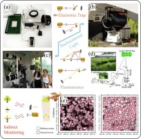

1. [Download : Download high-res image (200KB)](https://ars.els-cdn.com/content/image/1-s2.0-S1470160X23004442-ga1_lrg.jpg)
2. [Download : Download full-size image](https://ars.els-cdn.com/content/image/1-s2.0-S1470160X23004442-ga1.jpg)
- [Previous article in issue](https://www.sciencedirect.com/science/article/pii/S1470160X23004338)
- [Next article in issue](https://www.sciencedirect.com/science/article/pii/S1470160X23004521)

## Keywords

Laser

Remote sensing

Real-time monitoring

Insect

## 1. Introduction

Insects play essential roles in nature. As a result of the changes in climate and land use, the biomass and abundance of insects are also changing (van Klink et al., 2020, Uhler et al., 2021). Research has shown that insect biodiversity is associated with agriculture-related land-use change (Outhwaite et al., 2022). It is necessary to have an in-depth understanding of insect population activities. Conventional insect monitoring methods, which rely on sample collection, such as trapping, are time-consuming, laborious, and unsuitable for large-scale and rapid monitoring (Uhler et al., 2021, de Souza Amorim et al., 2022). In recent decades, [remote sensing](https://www.sciencedirect.com/topics/agricultural-and-biological-sciences/remote-sensing) methods for insect monitoring have seen rapid development, including solar [passive remote sensing](https://www.sciencedirect.com/topics/earth-and-planetary-sciences/passive-remote-sensing) (Jansson and Brydegaard, 2018), microwave and infrared [active remote sensing](https://www.sciencedirect.com/topics/earth-and-planetary-sciences/active-remote-sensing) (Lioy et al., 2021), acoustic sensing (Sinka et al., 2021), and high-speed photography based on machine vision (Clayborn and Clayborn, 2019). The monitoring method based on laser [remote sensing](https://www.sciencedirect.com/topics/earth-and-planetary-sciences/remote-sensing) technology has the advantages of high beam quality and diversified applications. It can monitor insect activity and estimate insect population density in real time (Genoud et al., 2021a, Genoud et al., 2023). However, remote sensing recognition can be difficult because of the lack of unified models that accurately describe insect scattering mechanisms and catalogues with quantitative [optical properties](https://www.sciencedirect.com/topics/earth-and-planetary-sciences/optical-property) (in SI units) for millions of insect species.

It is necessary to understand the remote sensing monitoring methods of insects fully. In the previous reviews, Brydegaard and Svanberg. (2018) introduced how light interacts with animals, and active and passive [optical remote sensing](https://www.sciencedirect.com/topics/earth-and-planetary-sciences/optical-remote-sensing) methods for monitoring animals, showing the advantages and limitations of optical methods in monitoring animals such as birds, [aquatic species](https://www.sciencedirect.com/topics/agricultural-and-biological-sciences/aquatic-species), and insects. In addition, Bieganowski et al. (2021) introduced a variety of [optical sensors](https://www.sciencedirect.com/topics/earth-and-planetary-sciences/optical-measuring-instrument) for monitoring crop damage caused by insects and identifying insect species. Noskov et al. (2021) introduced the development of entomological radar, such as harmonic radar and lidar. van Klink et al. (2022) introduced the application status of radar, computer vision, and other technologies in insect monitoring. In these reviews, only a few paragraphs introduce laser-based [remote sensing methods](https://www.sciencedirect.com/topics/earth-and-planetary-sciences/remote-sensing-method), which do not fully explain the advantages and limitations of different types of laser [remote sensing technology](https://www.sciencedirect.com/topics/earth-and-planetary-sciences/remote-sensing-technology) in monitoring insects, as well as the characteristics of the application. Moreover, they also do not comprehensively introduce the specific research.

Among the available laser remote sensing monitoring methods for insects, the method based on an electronic trap has a small probe volume, so it is more suitable for application when combined with the trapping device (Silva et al., 2015). The method based on backscattered light is more suitable for insect monitoring in the field. In this method, the pulsed laser-based monitoring is more suitable for free space monitoring (Kovalev and Eichinger, 2004, Tauc et al., 2019), and the continuous-wave laser-based monitoring can distinguish different insect clusters in the field, mainly because of the work done by researches in data analysis (Brydegaard et al., 2020). However, the fluorescence-based method offers the ability to monitor dye-labelled insects in clusters (Guan et al., 2010, Månefjord et al., 2022). In addition, the scanning and mapping capabilities of lidar are applied to indirectly monitor insect population activity (Solberg et al., 2006) because lidar offers a unique ability to map the [forest canopy](https://www.sciencedirect.com/topics/earth-and-planetary-sciences/forest-canopy) to assess the gathering and migration of herbivorous insect populations and aid in predicting the explosive growth of pest populations (Müller and Brandl, 2009, Meng et al., 2018). Compared with sampling monitoring methods, such as light trapping or chemical trapping (de Souza Amorim et al., 2022), it can provide real-time, non-contact measurements with low labour costs, which is advantageous for practical applications (Zhu et al., 2017, Genoud et al., 2021b).

This review focuses on laser remote sensing methods for insect monitoring. Previous reviews related to insect monitoring summarised the development status and prospects of many technologies, including computer vision, radar, and even the monitoring targets were not limited to insects (Daniel Kissling et al., 2013, Brydegaard and Svanberg, 2018, Bieganowski et al., 2021, Noskov et al., 2021, Van Klink et al., 2022). Although a comprehensive summary of the contribution of remote sensing technology to insect monitoring can enable researchers to understand this field quickly, however, the limitation is that it is unable to introduce in detail the advantages and limitations of a specific remote sensing technology (such as laser remote sensing) in insect monitoring, and what kind of system structure is used in different applications. Laser remote sensing technology is innovative in insect monitoring applications, enabling researchers to understand insect behaviour patterns more accurately (Brydegaard et al., 2020). In the future, laser remote sensing technology will have a broad application prospect in monitoring insects, and a detailed introduction to this monitoring method is necessary.

## 2. Materials and methods

The information in this review was obtained from commonly used databases, such as Google Scholar (https://scholar.google.com/), focusing on insect monitoring based on laser remote sensing. We randomly combined insect-related words such as insect, honeybee, moth, and mosquito with terms such as laser, monitoring, and remote sensing as keywords and mainly retrieved the last 20 years of relevant research.

When grouping the relevant literature, we focused on the application of laser remote-sensing technology. Laser remote sensing systems based on different principles are suitable for various applications. Firstly, the electronic trap-based system monitors the insect as it passes through the trap space, recording and analysing the extinction and scattering phenomena caused by the insect can obtain information about it (subchapter number is '3. Electronic trap-based monitoring method') (Silva et al., 2015). Secondly, the lidar that collects backscattered light or fluorescence is suitable when monitoring insect clusters in an [open space](https://www.sciencedirect.com/topics/agricultural-and-biological-sciences/open-space). Backscattered light-based lidar (Brydegaard et al., 2020) and Fluorescence-based lidar (Månefjord et al., 2022) each have unique applications and will be introduced in two parts (subchapter number is '4′ and '5′). According to the specific measurement and analysis methods, this content of the backscattered light-based lidar is further divided into two parts, namely: Pulsed laser-based monitoring system (Chen et al., 2014a), Continuous-wave laser-based monitoring system (Genoud et al., 2018b). Finally, we summarise an indirect monitoring method (subchapter number is '6′), which does not directly target the insect, but through the airborne lidar to scan the tree canopy structure to research the activity of the herbivorous insect population (Meng et al., 2018).

## 3. Electronic trap-based monitoring method

The optical system based on the electronic trap can be used directly to monitor insects. When an insect passes through the “trap” space between the laser source and the photodetector of the system, its body and wings will block or scatter the light, causing [light intensity](https://www.sciencedirect.com/topics/earth-and-planetary-sciences/luminous-intensity) changes at the photodetector. A single-pass insect can be monitored by capturing and processing these changes. The electronic trap-based monitoring method has been applied in many fields, such as [agricultural entomology](https://www.sciencedirect.com/topics/agricultural-and-biological-sciences/agricultural-entomology). For example, this method can be combined with Electric Spark Insect Control System (EDICS) to classify insects close to the trap and selectively kill pests (Chen et al., 2014a).

In the insect monitoring system based on the electronic trap, the [laser beam](https://www.sciencedirect.com/topics/earth-and-planetary-sciences/laser-beams) is shaped and homogenised using a lens, and the probe volume is only more than ten cubic decimeters (Chen et al., 2014b). Insects differ in their body structures and sizes, which can be used as a basis for identification (Balla et al., 2020). The monitoring system proposed by Jiao et al. (2018) decomposes the dynamic fall processes of insect specimens and effectively distinguishes insects of different sizes; the counting and classification accuracies for four types of pests in their experiments reached 98% and 86.7%, respectively.

The specific insect wing beat frequency (WBF) was used as the main recognition basis for more than 70 years; however, the photoacoustic sensors used to record the WBF were easily affected by environmental noise (Kahn and Offenhauser, 1949). In contrast, photoelectric sensors can effectively avoid interference from external noise. For example, Potamitis and Rigakis. (2015) monitored fruit flies under laboratory conditions and used [light modulation](https://www.sciencedirect.com/topics/earth-and-planetary-sciences/light-modulation) techniques to avoid external light interference.

Some different species of insects have similar WBF during flight; therefore, additional information must be acquired, e.g., by using the pwelch power estimate method with appropriate windowing to obtain frequency spectra, including fundamental frequencies and harmonics and extract spectral features for auxiliary classification (Silva et al., 2015). In a study of three species of mosquitoes with different genders, because two of the species (*Culex stigmatosoma* and *[Aedes aegypti](https://www.sciencedirect.com/topics/agricultural-and-biological-sciences/aedes-aegypti)*) had very similar wing beat frequencies, the error rate of classification based on the frequency spectrum was reduced from 18.13% to 12.43% when compared with the use of the fundamental frequency alone (Chen et al., 2014a). As shown in Fig. 1, Chen et al. (2014b) increased the time of intercept based on the frequency spectrum to identify insects. The classification accuracy of 10 species of insects, including six mosquito species of the same genus, exceeded 79%, and the accuracy rate for distinguishing the gender of the *Ae. aegypti* was as high as 99.4%.

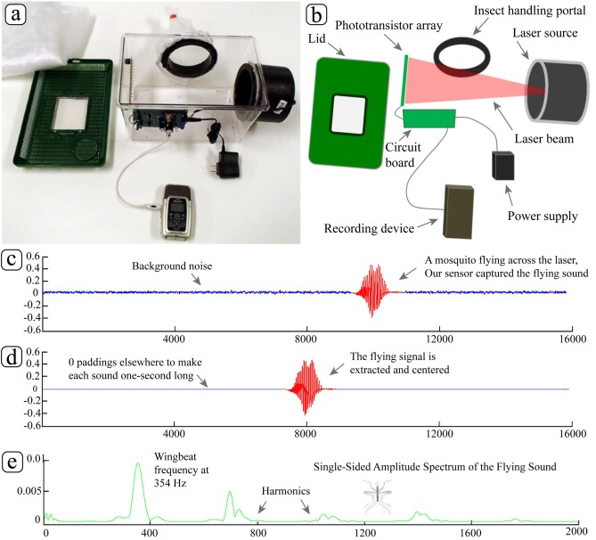

1. [Download : Download high-res image (546KB)](https://ars.els-cdn.com/content/image/1-s2.0-S1470160X23004442-gr1_lrg.jpg)
2. [Download : Download full-size image](https://ars.els-cdn.com/content/image/1-s2.0-S1470160X23004442-gr1.jpg)

Fig. 1. Electronic trap-based monitoring method. (a) Actual system layout. (b) Logical version of the system. The captured insect signal (c) is processed by padding with 0 s (d), and the pwelch power estimate method is performed to obtain the frequency spectrum (e). Reprinted from (Chen et al., 2014b).

Generally, the advantage of the electronic trap-based monitoring system is that it can be conveniently arranged in many locations, such as a tree in the forest, and the disadvantage is that it is usually used to identify passing insects one by one, which is inefficient. In the future, combining with other systems such as trapping will make electronic trap-based monitoring systems more widely used; developing technologies such as deep learning will also contribute to the more accurate identification of insect species (Kalfas et al., 2022).

## 4. Backscattered light-based monitoring method in open space

Collecting and analysing the backscattered light from laser-insect interactions enables real-time monitoring of insects. Backscattered light provides more information (coherent scattering produces more harmonic overtones) than light extinction. Although the monitoring system based on backscattered light can also be designed as an electronic trap structure for application (Rigakis et al., 2019), its advantage is the real-time monitoring of insect clusters in open space (Brydegaard et al., 2020).

In various applications, different types of lasers are used in the backscattered light-based monitoring method. We will introduce them in two parts: Pulsed and Continuous laser-based monitoring systems.

### 4.1. Pulsed laser-based monitoring system

The pulsed laser-based system is mainly used to monitor the activity of insects in free space. The system is set up to face the insect's active space, and the distance between the system and the target insect is calculated based on the time-of-flight principle.

In practical application, the background, such as plants, makes it challenging to extract insect signals: Bender et al. (2003) suffered from serious background interference when using the pulsed laser-based system to monitor insects. It is necessary to simplify the background or keep the optical path away from the ground. Under simplified background conditions, researchers successfully monitored honeybee activity on a feeding platform 1300 m away using a 355 nm laser with 30 pulses per second (1–40 mJ) (Bender et al., 2003). In addition, the pulse energy and the divergence angle affect the monitoring distance directly, and the farther the monitoring system is from the target, the lower the signal-to-noise ratio. Shaw et al. (2005) installed the optical system on a platform that could swing horizontally 1 m above the ground. They successfully identified honeybees' activity within an area of 1000 m<sup>2</sup> at a distance of 83 m using 100 mJ of 532 nm laser.

Shaw et al. (2005) found that the depolarisation degree of the honeybee’s body is higher than that of its wings, which had nothing to do with the direction of flight. In field experiments, the number of honeybee signals detected using co-polarized light was much greater than that detected when using depolarised light. With the research on the polarised light interaction with insects (Li et al., 2021), polarised light is widely used in insect monitoring, not limited to the pulsed laser-based system (Carlsten et al., 2011, Mullen et al., 2016). Studying the modulated [power spectrum](https://www.sciencedirect.com/topics/earth-and-planetary-sciences/power-spectra) of the insect’s wing beating allows researchers to extract insect signals from complex backgrounds (Repasky et al., 2006, Hoffman et al., 2007, Tauc, 2017). As shown in Fig. 2, Tauc et al. (2019) installed a wing-beat modulation lidar system on a two-dimensional tilted base. They received hundreds of insect signals within a 130 m range, enabling insect activity to be quantified at different times of the day. Although the information harvested was insufficient to distinguish insect species, monitoring in three-dimensional space has considerable value for practical application.

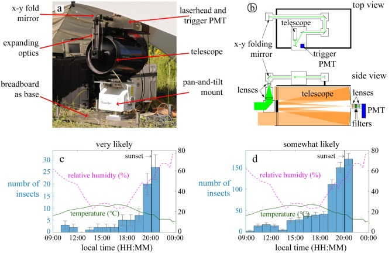

1. [Download : Download high-res image (529KB)](https://ars.els-cdn.com/content/image/1-s2.0-S1470160X23004442-gr2_lrg.jpg)
2. [Download : Download full-size image](https://ars.els-cdn.com/content/image/1-s2.0-S1470160X23004442-gr2.jpg)

Fig. 2. Pulsed laser-based monitoring system in [open space](https://www.sciencedirect.com/topics/agricultural-and-biological-sciences/open-space) (a) [Lidar](https://www.sciencedirect.com/topics/agricultural-and-biological-sciences/lidar) system in the field. (b) Schematic of the optical setup. (c), (d) Insect count histograms showing how active the insects are over time. Reprinted from (Tauc et al., 2019).

It should be noted that lidar systems for atmospheric aerosol monitoring have also been considered for insect migration monitoring. The European Aerosol Lidar Network has been shown to classify migratory species using single-shot lidar in atmospheric backscattering (Jansson et al., 2017). In addition, the ranging capability of lidar systems can be combined with reflectivity information collected by cloud radar to enable dynamic monitoring of the large-scale take-off and landing behaviour of insects in the height range of 200 m-2000 m at night (Wainwright et al., 2020).

In general, the pulsed laser-based monitoring system is mainly used to monitor the activity rhythm of insects. The low signal-to-noise ratio caused by the complex backgrounds is a factor that limits the development of the pulse method pulsed laser-based monitoring system. So, simplifying field backgrounds, using pulsed laser systems with higher repetition rates, and applying multi-band polarised lasers will make the pulsed laser-based monitoring system more widely used.

### 4.2. Continuous-wave laser-based monitoring system

The continuous-wave laser-based monitoring system is used for insect monitoring in open space through the Scheimpflug lidar designed on the triangulation ranging principle. The structure of the Scheimpflug lidar is shown in Fig. 3a. The laser emitter and the telescope are installed at a particular angle in the same direction, and the imaging detector is then arranged at the rear of the telescope at a specific angle. This triangulation principle is based on a unique arrangement of optical components that can obtain infinite focal depth (Brydegaard et al., 2017). The continuous-wave scattered light from short and long distances is focused onto different positions on the detector. Using the distance from the laser to the termination plane (e. g. black [neoprene](https://www.sciencedirect.com/topics/earth-and-planetary-sciences/chloroprene-resins) foam-covered board. Kouakou et al., 2020), the detector’s pixel size and the separation distance between the emitter and the collector, accurate target distance information is deduced by triangular inversion, which can achieve a higher sampling rate of kHz; however, the range resolution obtained by this method is nonuniform and decreases with increasing target distance (Brydegaard et al., 2014, Brydegaard et al., 2018a, Brydegaard et al., 2021).

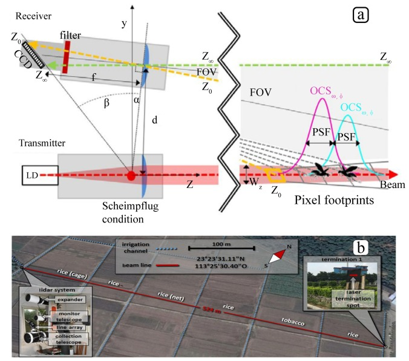

1. [Download : Download high-res image (593KB)](https://ars.els-cdn.com/content/image/1-s2.0-S1470160X23004442-gr3_lrg.jpg)
2. [Download : Download full-size image](https://ars.els-cdn.com/content/image/1-s2.0-S1470160X23004442-gr3.jpg)

Fig. 3. (a) Principle of Scheimpflug lidar based on triangulation. Reprinted from (Brydegaard et al., 2014), reproduced courtesy of The Electromagnetics Academy. (b) The illustrations show an aerial view of a farm marked with the spatial transect, the [lidar](https://www.sciencedirect.com/topics/earth-and-planetary-sciences/optical-radar) system's settings and the laser interface. Reprinted from (Malmqvist et al., 2018).

In most field monitoring, a termination plane will be set at the endpoint to monitor insect activity within the static spatial transect between the Scheimpflug lidar and beam termination, as shown in Fig. 3(b). The system can distinguish different insect clusters and evaluate insect flight speeds perpendicular to the optical axis (Li et al., 2020). The spatial transect is usually set at the height of 3–5 m above the ground, and the area of the probe volume cross-section is typically about 2000 mm<sup>2</sup> at a range of 50 m from the lidar and, due to the divergence angle of the laser beam, will be about 10,000 mm<sup>2</sup> at a range of 500 m. The depth of the probe volume depends on the situation at the actual site, which is 100–600 m in most studies (Zhu et al., 2017, Jansson et al., 2021), but researchers have also identified insect signals at ranges up to several kilometres (Brydegaard et al., 2014, Malmqvist et al., 2016).

The optical cross-section can reflect the size of the insect’s body and wings. It can be calculated from the backscattered [light intensity](https://www.sciencedirect.com/topics/earth-and-planetary-sciences/luminous-intensity), which is the product of the geometric projected area and the reflectivity. The signal intensity can be calibrated by terminating the laser beam on a neoprene foam-covered board with 2% Lambert reflectivity (Brydegaard, 2015; Malmqvist et al., 2018, Jansson et al., 2021). As shown in Fig. 4(a), the shape of the optical cross-section over time can be understood to be in two parts: the low-frequency envelope part from the rough insect body and the high-frequency oscillation part from the smooth wing. Insects of different sizes generally have different optical cross-sections (Brydegaard et al., 2016). Kirkeby et al. (2016) observed differences in optical cross-section shapes of the bodies and wings of three insect clusters on farmland in Sweden.

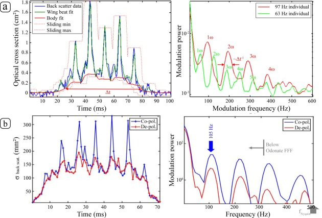

1. [Download : Download high-res image (502KB)](https://ars.els-cdn.com/content/image/1-s2.0-S1470160X23004442-gr4_lrg.jpg)
2. [Download : Download full-size image](https://ars.els-cdn.com/content/image/1-s2.0-S1470160X23004442-gr4.jpg)

Fig. 4. (a) Optical cross-section information of an insect captured from backscattered light (left) and from time-modulated frequency spectra of two insect species (right). Reprinted from (Brydegaard et al., 2014), reproduced courtesy of The Electromagnetics Academy. (b) Insect signal from polarised lidar, including the co-polarized and depolarised optical cross-sections (left) and corresponding frequency spectra, including harmonics (right). Reprinted from (Brydegaard et al., 2018b).

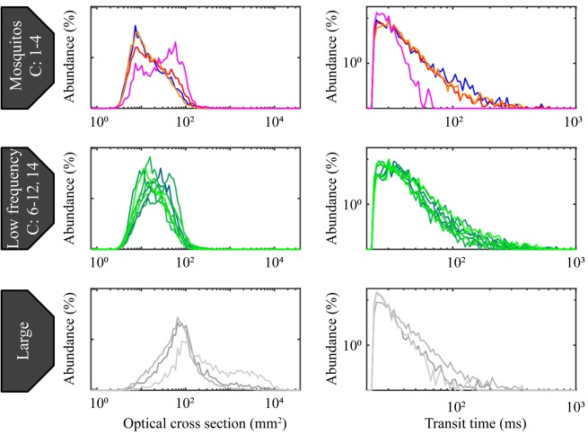

1. [Download : Download high-res image (375KB)](https://ars.els-cdn.com/content/image/1-s2.0-S1470160X23004442-gr5_lrg.jpg)
2. [Download : Download full-size image](https://ars.els-cdn.com/content/image/1-s2.0-S1470160X23004442-gr5.jpg)

Fig.5. Optical cross-section histograms (left) and transit time histograms (right) labelled as mosquitoes (top), insects with low wing beat frequencies (middle), and other larger organisms (bottom). Reprinted from (Jansson et al., 2021).

Moreover, the hair and wings of insects show different scattering characteristics at different laser wavelengths. A single-band laser is too coarse for species identification of insects with similar body structure and size, and combining multi-band lasers provides significant advantages (Gebru et al., 2018). Using a multi-band polarised laser monitoring system to observe mosquitoes flying freely inside an airtight chamber, researchers observed differences among the optical cross-sections for 924 nm, 1320 nm, and 1550 nm laser beams (Genoud et al., 2019). In addition, Gebru et al. (2018) also analysed mosquitoes' [polarisation characteristics](https://www.sciencedirect.com/topics/earth-and-planetary-sciences/polarization-characteristics) under laboratory conditions. They found that parameters such as the body- and wing-spectral ratios were almost unaffected by the flight direction, and *Anopheles coluzzii* and *A. arabiensis* were distinguished easily. The main reason for this phenomenon is that insect tissues with different degrees of [melanisation](https://www.sciencedirect.com/topics/agricultural-and-biological-sciences/melanization), and [chitins](https://www.sciencedirect.com/topics/earth-and-planetary-sciences/chitin) with different thicknesses, show different reflectivity characteristics in the three laser bands. In several widely used laser bands, melanin can absorb part of the 808 nm laser light, while the 1320 nm light has the strongest signal because it is almost not absorbed by the insect body (Gebru et al., 2018, Jacques, 2013, Tuchin, 2016). Brydegaard. (2014) found that short-wave infrared light showed stronger signals from insects than traditional 532 nm laser light, and it was even more suitable for insect monitoring than near-infrared light.

When researching insect activity based on a continuous-wave laser-based monitoring system, in addition to the analysis of optical cross-section, the WBF from insect clusters in the field is also considered (Rydhmer et al., 2022). The WBF is related to the individual factors of each specific insect, e.g., the area of their wings and membrane thickness (de Nadai et al., 2021), and also affected by external conditions such as [wind speed](https://www.sciencedirect.com/topics/earth-and-planetary-sciences/wind-velocity) (Parmezan et al., 2021). Backscattered light from an insect’s smooth wings shows an oscillating trend over time, which has been discussed previously; the change in signal intensity over time can be regarded as the fundamental WBF (Fig. 4), the oscillation peak signal in the time domain can be transformed into a harmonic overtone in the frequency domain (Brydegaard et al., 2018b). In field application, during four days, five nights, and an annular [solar eclipse](https://www.sciencedirect.com/topics/earth-and-planetary-sciences/solar-eclipse) in Africa, researchers observed a variety of insect clusters with different [modulation frequency](https://www.sciencedirect.com/topics/earth-and-planetary-sciences/frequency-modulation) spectra. By comparing these spectra with data analysed previously in the laboratory, they could roughly identify possible *Anopheles* and other insect species and record the spatiotemporal activities of the different insect clusters (Brydegaard et al., 2020).

Although the WBF is sufficiently accurate to distinguish between male and female mosquitoes' high-frequency and low-frequency signals, the beat frequency alone is sometimes insufficient to distinguish between mosquito species. Genoud et al., (2018) placed three types of mosquitoes, including *[Aedes albopictus](https://www.sciencedirect.com/topics/agricultural-and-biological-sciences/aedes-albopictus)*, in a 1.25-m-long plexiglass tube 3 m, allowing them to fly freely. After studying the collected 1320 nm backscattered light, they found that the overall gender classification accuracy based on the WBF can reach 96.5%. However, the overall accuracy was reduced to 62.3% when the species needed further distinction. This situation may be more pronounced when experiments occur at sites with more insect species (Pile, 2018).

However, combining the many independent predictive variables in backscattered light with the WBF will improve identification performance (Malmqvist et al., 2016, Genoud et al., 2018b). As shown in Fig. 6, under controlled laboratory conditions, Genoud et al. (2019) used a dual-wavelength polarised laser system to record the collected scattering signals. Among the many specific variables obtained, combining the body depolarisation ratio with the WBF was very effective in identifying pregnancy in the *Culex* genus. In Newton, New Jersey, Genoud et al. (2021b) researchers observed and recorded the activity rhythms of four different insect clusters based on their wing beat frequencies, optical cross-sectional ratios of the body to wing, speeds, and other variables, and also inferred the insect species that may have been included in these clusters.

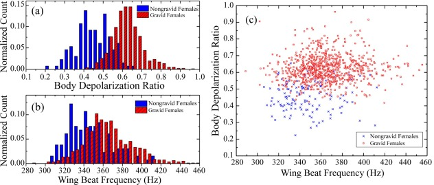

1. [Download : Download high-res image (421KB)](https://ars.els-cdn.com/content/image/1-s2.0-S1470160X23004442-gr6_lrg.jpg)
2. [Download : Download full-size image](https://ars.els-cdn.com/content/image/1-s2.0-S1470160X23004442-gr6.jpg)

Fig. 6. (a), (b) Normalized frequency histograms and (c) scatter plot for identification of female Culex gravid using two specific parameters: the body depolarisation ratio and the WBF. The simultaneous use of two predictive variables to distinguish gravid from non-gravid mosquitoes is better than using a single predictive variable. Reprinted from (Genoud et al., 2019).

In the actual experiment, researchers need to consider the effect of weather. Extreme weather does affect monitoring, but it rarely happens, so we will discuss common weather (rainfall) as an example. The first aspect is the impact on the ability of the system to monitor insects, which can be solved by signal processing because insects and raindrops have different speeds and directions (Zhu et al., 2017). The second aspect is protecting monitoring systems from rainfall and ensuring the power supply. Brydegaard et al. (2009) used a vehicle-mounted monitoring system to avoid weather effects and a diesel generator to power the system. While monitoring insect activity on a farm in southeastern Tanzania, Brydegaard et al. (2020) also used a small 2-kW motor generator to power a lidar system installed in a house near the farm. For long periods of continuous monitoring, researchers often connect the system to a wired electrical network, as in the case of Genoud et al. (2021b), who chose to conduct insect monitoring for three months in grassland in a temperate primary forest where the monitoring system could be connected to the electrical network. In addition, Field experiment is necessary to avoid the damage the laser may bring to human eyes. Brydegaard et al. (2020) introduce the total emitted intensity and the intensity at the aperture and termination of the system they used and conclude that this beam is unsafe for the human eye. Usually, researchers will avoid the harm caused by the laser beam to people, such as setting the laser beam high above the ground to avoid public contact and using a surveillance camera with an [infrared filter](https://www.sciencedirect.com/topics/earth-and-planetary-sciences/infrared-filter) to observe the state of the beam on the terminal target at any time (Brydegaard et al., 2020), or setting the experimental site in an area surrounded by a fence to avoid contact between non-researchers and the laser beam (Genoud et al., 2021b).

Finally, the continuous wave lidar system is suitable for monitoring insects in the open space and can distinguish and identify different species of insect clusters (Jansson et al., 2020). Moreover, it has many advantages over pulsed laser-based systems, such as kHz sample rates (Brydegaard et al., 2014). The known climatic and [geographical distribution](https://www.sciencedirect.com/topics/agricultural-and-biological-sciences/geographical-distribution) of insects can also assist in the identification of insects in the field; for example, the distribution of mosquitoes is affected by the environment and different species are distributed in different areas (Gorris et al., 2021, Gbogbo et al., 2022), the database can be established and improved according to the existing research, which will provide a reference for insect remote sensing. With the future development and application of machine learning and other technologies (Kirkeby et al., 2021, Genoud et al., 2020), the backscattered light-based monitoring method will perform better in the field of insect monitoring.

## 5. Fluorescence-based monitoring method

Fluorescence is a photoluminescence-type phenomenon, and in the process of laser-induced fluorescence, the molecule is excited to produce fluorescence by the radiative transition. The remote sensing monitoring method based on fluorescence has good selectivity and is also used in monitoring insects. (Guan et al., 2010, Lu et al., 2020). The fluorescence-based monitoring method is similar in system structure and application to the backscattered light-based monitoring method; either based on a pulsed laser-based system structure or a continuous-wave laser-based system structure can be used to monitor insects' fluorescence in open space.

The 355 nm and 266 nm wavelengths are commonly used because insect fluorescence characteristics are related to the nanostructures of their tissues (Brydegaard et al., 2010, Stavenga, 2014). When insect specimens were excited by laser light at the 355 nm and 266 nm wavelengths, researchers were able to observe a slight difference between the fluorescence spectra of male and female *Calopteryx splendens* at a distance of 60 m within the 400–600 nm wavelength range (Brydegaard et al., 2009). Furthermore, almost the same method was used to detect planthopper specimens; spectral differences were also observed among *planthopper* specimens of different genders in the 400–750 nm wavelength range (Mei et al., 2012). These static tests demonstrated the potential of insect monitoring techniques based on fluorescence (Li et al., 2016). However, although the autofluorescence of the insect body structure can be used as a basis for insect species identification, the autofluorescence yield of insects is usually low. The fluorescence signal from the insect itself is weak, and there may be background interference in field experiments, which would not allow direct monitoring of insect activity in the field by insect autofluorescence (Bender et al., 2003, Jansson et al., 2017).

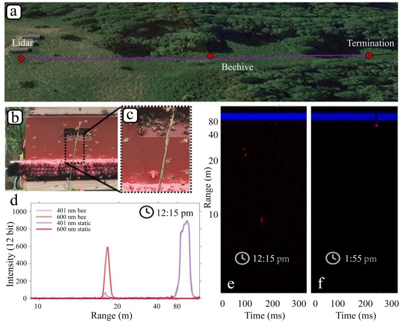

1. [Download : Download high-res image (574KB)](https://ars.els-cdn.com/content/image/1-s2.0-S1470160X23004442-gr7_lrg.jpg)
2. [Download : Download full-size image](https://ars.els-cdn.com/content/image/1-s2.0-S1470160X23004442-gr7.jpg)

Fig. 7. Dye fluorescence monitoring of honeybees. (a) Schematic diagram of the on-site layout of the fluorescence lidar. (b), (c) [Beehive](https://www.sciencedirect.com/topics/agricultural-and-biological-sciences/beehives) with automatic dye marking device and bees flying around it. (d) Fluorescent lidar captures the signals from dye-marked bees. (e), (f) Two recorded events of marked bees entering the [laser beam](https://www.sciencedirect.com/topics/earth-and-planetary-sciences/laser-beams). Reprinted from (Månefjord et al., 2022).

In practical application, the monitoring of insect activity by insect autofluorescence will be disturbed by background fluorescence, which needs to be realised in a clean background. The advantage of the fluorescence-based monitoring method is that it allows the activity of one or more insects labelled with dye in the cluster to be monitored, which is also impossible to achieve by other laser-based monitoring methods, such as the backscattered light-based method.

## 6. Indirect monitoring method

The activity of herbivorous insects is affected by multiple conditions (such as climate) (Alalouni et al., 2013). The indirect monitoring method refers to the using the mapping capabilities of lidar to analyse the impact of insects on tree canopy structure and thus provide an indirect understanding of the information of insect populations. Compared to the backscattered light-based direct monitoring method (Li et al., 2021), this method has a more extended monitoring period but can be applied to complex environments such as forests (Müller and Brandl, 2009). Lidar used for indirect monitoring usually has a small beam divergence angle and realises distance resolution based on the time-of-flight principle. The system performs static or dynamic scanning through components such as [galvanometers](https://www.sciencedirect.com/topics/earth-and-planetary-sciences/galvanometer) and then uses post-processing software to reconstruct the target point cloud for the mapping tree structure (Zhao et al., 2017, Barnes et al., 2017a, Barnes et al., 2017b).

[Terrestrial laser scanning](https://www.sciencedirect.com/topics/earth-and-planetary-sciences/terrestrial-laser-scanning) (TLS) can map the structures of individual trees. The lidar is installed on the ground to perform static or 360° surround scanning of the trees. Jacobs et al. (2022) performed many field experiments in oak/mixed forests using TLS to map and quantify [leaf area](https://www.sciencedirect.com/topics/agricultural-and-biological-sciences/leaf-area) changes in a single tree caused by gypsy moths. By setting up a TLS observatory on-site, Orwig et al. (2018) also monitored the entire process, from loss of branches and leaves to death in hemlock trees after infection by the [hemlock woolly adelgid](https://www.sciencedirect.com/topics/agricultural-and-biological-sciences/hemlock-woolly-adelgid).

Airborne lidar systems have flying altitudes of approximately 200–1000 m and can easily monitor large-scale forests (Solberg et al., 2006, Bombi et al., 2019). Zhao et al. (2017) used airborne lidar to map several forest plots with areas of 100 m × 100 m in Heilongjiang Province, China (Fig. 8). When using their cross-sectional analysis method to process the lidar data and compared the results with the artificially mapped canopy, the overall average accuracy for sample plots from [coniferous forests](https://www.sciencedirect.com/topics/earth-and-planetary-sciences/coniferous-forest) and other tree species was more than 80%. Additionally, Solberg et al. (2006) conducted three field experiments using airborne lidar on a flat river valley area of 21 km<sup>2</sup> over four months. They monitored a forest with [pine](https://www.sciencedirect.com/topics/agricultural-and-biological-sciences/pinus) as its main tree species from the beginning of the attack by *pine sawfly* to the recovery of health in August. The deciduous map showed the changing trends in the leaf area index during this period.

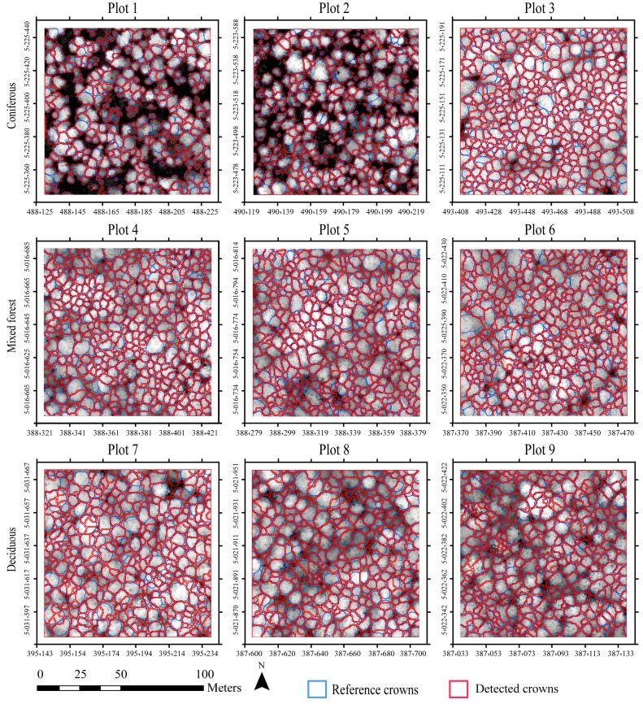

1. [Download : Download high-res image (3MB)](https://ars.els-cdn.com/content/image/1-s2.0-S1470160X23004442-gr8_lrg.jpg)
2. [Download : Download full-size image](https://ars.els-cdn.com/content/image/1-s2.0-S1470160X23004442-gr8.jpg)

Fig. 8. Detected tree crowns for nine sampling forests, where the blue boundaries represent reference crowns, and the red boundaries represent detected crowns by airborne lidar. Reprinted from (Zhao et al., 2017). (For interpretation of the references to colour in this figure legend, the reader is referred to the web version of this article.)

The pulse laser is better able to penetrate the canopy to obtain structural information about the canopy profile, but [remote sensing methods](https://www.sciencedirect.com/topics/earth-and-planetary-sciences/remote-sensing-method) such as [hyperspectral images](https://www.sciencedirect.com/topics/earth-and-planetary-sciences/hyperspectral-image) (Nagler et al., 2014, Abdullah et al., 2019) have also been used to study the canopy structure of trees. A combination of the various remote sensing methods can often be used to obtain more accurate canopy information (Schneider et al., 2017, Lin et al., 2019). Meng et al. (2018) performed lidar mapping and hyperspectral observations of changes in the canopy structure and spectrum caused by the gypsy moth in an oak-mixed forest on Long Island, New York, in the summer of 2016 (Fig. 9). They found that the two sets of results showed good agreement with each other. Compared with using any single type of method alone, combining the two techniques provides additional information and better prediction ability for mapping the defoliation, which also provides a new approach for monitoring the activities of herbivorous insect populations.

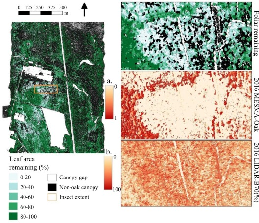

1. [Download : Download high-res image (859KB)](https://ars.els-cdn.com/content/image/1-s2.0-S1470160X23004442-gr9_lrg.jpg)
2. [Download : Download full-size image](https://ars.els-cdn.com/content/image/1-s2.0-S1470160X23004442-gr9.jpg)

Fig. 9. Remaining [leaf area](https://www.sciencedirect.com/topics/agricultural-and-biological-sciences/leaf-area) map of the area under study (left), where the inset sequentially shows the remaining foliage in the rectangles marked in the leaf area map, the result of the spectrometer analysis, and the results of the lidar analysis using LIDAR-B70 (right). Reprinted from (Meng et al., 2018).

Generally, indirect monitoring of insects can be beneficial in tracking herbivorous insect populations; even if its monitoring period is long, it can conveniently monitor large forest areas. However, mapping based on lidar and the subsequent implementation algorithm is complex, and there is still a need for more stable and universal post-processing software, which represents a development direction.

## 7. Concluding remarks and future perspectives

Laser-based monitoring methods have been applied to entomology research, and their key advantage is that they can achieve real-time monitoring and have various applications. Table 1 collates some of the applications and major findings from these methods.

Table 1. Specific applications and major findings of several laser-based insect monitoring methods.

[output not shown]

The various laser-based monitoring methods have both advantages and limitations. Thus, scientists and engineers must select the most suitable monitoring methods for different applications. Table 2 compares the characteristics of the various laser-based monitoring methods. Different methods are suitable for different applications such as farmland or forest. The probe volume of the electronic trap-based monitoring method is usually small and can be combined with the trapping device. The backscattered light-based monitoring method has a high sampling frequency. It can distinguish and identify different insect clusters, so it is suitable for open farmland and other places. The characteristic of the fluorescence-based method is that it can monitor one or more dye-labelled insects in the cluster and study their activities. The indirect monitoring method can be used to study the activities of herbivorous insect populations in the forest.

Table 2. Comparison of the Unique applications of various laser-based methods used to monitor insects and the laser wavelengths used.

| **Method** | **Laser Sources** **（as an example)** | **Applications** | **Advantages** | **Refs** |
| --- | --- | --- | --- | --- |
| Electronic trap-based | 780 nm continuous wave laser | The system generally takes up a small space to monitor insects through the probe volume. | More suitable for application in combination with trapping and other methods. | Jiao et al., 2018, Chen et al., 2014b |
| Backscattered light-based (Pulsed laser) | 532 nm pulsed laser | Monitoring insects in open space. (Collect backscattered light) | Realise three-dimensional scanning to monitor insects. | Tauc et al., 2019 |
| Backscattered light-based (Continuous-wave laser) | 808 nm continuous wave laser |  | Distinguish and identify insect species in the open space. | Kirkeby et al., 2016 |
|  |  |  |  | Brydegaard et al., 2020 |
| Fluorescence-based | 355 nm pulsed laser & 401 nm continuous wave laser | Monitoring fluorescence from insects in open space. (Collect fluorescence) | Monitoring of dye-labelled insects in clusters. | Mei et al., 2012, Månefjord et al., 2022 |
| Indirect monitoring | 1064 nm pulsed laser | Monitoring of herbivorous insect populations causing changes in tree canopy structure. | Predicting pest infestations and tracking the activity of insect populations. | Solberg et al., 2006 |

With the ongoing development of science, more scientists may contribute to this field, and applying better sensors and post-processing algorithms will contribute to laser monitoring methods. First of all, the improvement of hardware performance is helpful for monitoring; for example, the improvement of the detector can make the sampling frequency of the Scheimpflug lidar higher, and the lens module with a smaller divergence angle (including laser and collimating lens) can improve the mapping ability of indirect monitoring method. Finally, a more effective signal processing method will improve the data analysis ability of the system. Generally speaking, the method of insect monitoring based on laser remote sensing is necessary and practical. It has been widely used in entomology and has a good development prospect.

## Declaration of Competing Interest

The authors declare that they have no known competing financial interests or personal relationships that could have appeared to influence the work reported in this paper.

## Acknowledgment

This research was financially supported by Strategic Priority Research Program of Chinese Academy of Sciences, Grant No. XDA26010304. Beijing Agriculture Innovation Consortium (BAIC08-2022) and National & Local Joint Engineering Laboratory for Agricultural Internet of Things (PT2022-23). We thank David MacDonald, MSc, from Liwen Bianji (Edanz) (www.liwenbianji.cn/) for editing the English text of a draft of this manuscript.

## Data availability

Data will be made available on request.

## References

1. Abdullah et al., 2019

   H. Abdullah, A.K. Skidmore, R. Darvishzadeh, M. Heurich, N. Pettorelli, M. Disney

   Sentinel-2 accurately maps green-attack stage of European spruce bark beetle (Ips typographus, L.) compared with Landsat-8

   Remote. Sens. Ecol. Conserv., 5 (1) (2019), pp. 87-106

   [CrossRef](https://doi.org/10.1002/rse2.93)[View in Scopus](https://www.scopus.com/inward/record.url?eid=2-s2.0-85052391057&partnerID=10&rel=R3.0.0)Google Scholar
2. Alalouni et al., 2013

   U. Alalouni, M. Schädler, R. Brandl

   Natural enemies and environmental factors affecting the population dynamics of the gypsy moth

   J. Appl. Entomol., 137 (2013), pp. 721-738, 10.1111/jen.12072

   [View in Scopus](https://www.scopus.com/inward/record.url?eid=2-s2.0-84889605417&partnerID=10&rel=R3.0.0)Google Scholar
3. Balla et al., 2020

   E. Balla, N. Flórián, V. Gergócs, L. Gránicz, F. Tóth, T. Németh, M. Dombos

   An opto-electronic sensor-ring to detect arthropods of significantly different body sizes

   Sensors, 20 (2020), p. 982, 10.3390/s20040982

   [View in Scopus](https://www.scopus.com/inward/record.url?eid=2-s2.0-85079505879&partnerID=10&rel=R3.0.0)Google Scholar
4. Barnes et al., 2017a

   C. Barnes, H. Balzter, K. Barrett, J. Eddy, S. Milner, J.C. Suárez

   Individual tree crown delineation from airborne laser scanning for diseased larch forest stands

   Remote Sens., 9 (2017), p. 231, 10.3390/rs9030231

   [View in Scopus](https://www.scopus.com/inward/record.url?eid=2-s2.0-85019351419&partnerID=10&rel=R3.0.0)Google Scholar
5. Barnes et al., 2017b

   C. Barnes, H. Balzter, K. Barrett, J. Eddy, S. Milner, J.C. Suárez

   Airborne laser scanning and tree crown fragmentation metrics for the assessment of Phytophthora ramorum infected larch forest stands

   For. Ecol. Manag., 404 (2017), pp. 294-305, 10.1016/j.foreco.2017.08.052

   [View PDF](https://www.sciencedirect.com/science/article/pii/S0378112717309362/pdfft?md5=899cf2fc2eda29542aef2e110592be3f&pid=1-s2.0-S0378112717309362-main.pdf)[View article](https://www.sciencedirect.com/science/article/pii/S0378112717309362)[View in Scopus](https://www.scopus.com/inward/record.url?eid=2-s2.0-85028916284&partnerID=10&rel=R3.0.0)Google Scholar
6. Bender et al., 2003

   Bender, S.F.A., Rodacy, P.J., Schmitt, R.L., Hargis, P.J., Johnson, M.S., Klarkowski, J.R., Magee, G.I., Bender, G.L., 2003. Tracking honey bees using LIDAR (light detection and ranging) technology. Sandia Report SAND2003-0184, Sandia National Laboratory, Albuquerque, United States. 87185. 10.2172/808625.

   Google Scholar
7. Bieganowski et al., 2021

   A. Bieganowski, K.H. Dammer, A. Siedliska, M. Bzowska-Bakalarz, P.K. Bereś, K. Dąbrowska-Zielińska, M. Pflanz, M. Schirrmann, A. Garz

   Sensor-based outdoor monitoring of insects in arable crops for their precise control

   Pest Manag. Sci., 77 (2021), pp. 1109-1114, 10.1002/ps.6098

   [View in Scopus](https://www.scopus.com/inward/record.url?eid=2-s2.0-85092169540&partnerID=10&rel=R3.0.0)Google Scholar
8. Bombi et al., 2019

   P. Bombi, V. Gnetti, E. D’Andrea, B. De Cinti, A.V. Taglianti, M.A. Bologna, G. Matteucci

   Identifying priority sites for insect conservation in forest ecosystems at high resolution: the potential of LiDAR data

   J. Insect Conserv., 23 (2019), pp. 689-698, 10.1007/s10841-019-00162-w

   [View in Scopus](https://www.scopus.com/inward/record.url?eid=2-s2.0-85067000148&partnerID=10&rel=R3.0.0)Google Scholar
9. Brydegaard et al., 2009

   M. Brydegaard, Z. Guan, M. Wellenreuther, S. Svanberg

   Insect monitoring with fluorescence lidar techniques: feasibility study

   Appl. Opt., 48 (2009), pp. 5668-5677, 10.1364/AO.48.005668

   [View in Scopus](https://www.scopus.com/inward/record.url?eid=2-s2.0-70350290294&partnerID=10&rel=R3.0.0)Google Scholar
10. Brydegaard et al., 2010

    M. Brydegaard, P. Lundin, Z. Guan, A. Runemark, S. Åkesson, S. Svanberg

    Feasibility study: fluorescence lidar for remote bird classification

    Appl. Opt., 49 (2010), pp. 4531-4544, 10.1364/AO.49.004531

    [View in Scopus](https://www.scopus.com/inward/record.url?eid=2-s2.0-77955892566&partnerID=10&rel=R3.0.0)Google Scholar
11. Brydegaard et al., 2014

    M. Brydegaard, A. Gebru, S. Svanberg

    Super resolution laser radar with blinking atmospheric particles––Application to interacting flying insects

    Progress Electromagn. Res., 147 (2014), pp. 141-151, 10.2528/PIER14101001

    [View in Scopus](https://www.scopus.com/inward/record.url?eid=2-s2.0-84926006821&partnerID=10&rel=R3.0.0)Google Scholar
12. Brydegaard, 2015

    M. Brydegaard

    Towards quantitative optical cross sections in entomological laser radar - potential of temporal and spherical parameterizations for identifying atmospheric fauna

    PLoS One, 10 (8) (2015), p. e0135231

    [CrossRef](https://doi.org/10.1371/journal.pone.0135231)[View in Scopus](https://www.scopus.com/inward/record.url?eid=2-s2.0-84943182211&partnerID=10&rel=R3.0.0)Google Scholar
13. Brydegaard et al., 2016

    M. Brydegaard, A. Gebru, C. Kirkeby, S. Åkesson, H. Smith, B. Gross, F. Moshary, M. Arend

    Daily evolution of the insect biomass spectrum in an agricultural landscape accessed with lidar

    EPJ Web of Conferences., 119 (2016), p. 22004

    [CrossRef](https://doi.org/10.1051/epjconf/201611922004)[View in Scopus](https://www.scopus.com/inward/record.url?eid=2-s2.0-84976285871&partnerID=10&rel=R3.0.0)Google Scholar
14. Brydegaard et al., 2017

    M. Brydegaard, E. Malmqvist, S. Jansson, J. Larsson, S. Török, G. Zhao

    Proceedings of the The Scheimpflug lidar method. Lidar Remote Sensing for Environmental Monitoring, Proc.SPIE, San Diego, United States, 10406 (2017), p. 104060I

    [View in Scopus](https://www.scopus.com/inward/record.url?eid=2-s2.0-85039060885&partnerID=10&rel=R3.0.0)Google Scholar
15. Brydegaard et al., 2018a

    M. Brydegaard, J. Larsson, S. Török, E. Malmqvist, G. Zhao, S. Jansson, M. Andersson, S. Svanberg, S. Åkesson, F. Laurell, J. Bood, D. Nicolae, A. Makoto, A. Vassilis, D. Balis, A. Behrendt, A. Comeron, F. Gibert, E. Landulfo, M.P. McCormick, C. Senff, I. Veselovskii, U. Wandinger

    Short-Wave infrared atmospheric scheimpflug lidar

    EPJ Web of Conferences., 176 (2018), p. 01012

    [CrossRef](https://doi.org/10.1051/epjconf/201817601012)[View in Scopus](https://www.scopus.com/inward/record.url?eid=2-s2.0-85045888744&partnerID=10&rel=R3.0.0)Google Scholar
16. Brydegaard et al., 2018b

    M. Brydegaard, S. Jansson, M. Schulz, A. Runemark

    Can the narrow red bands of dragonflies be used to perceive wing interference patterns

    Ecol. Evol., 8 (2018), pp. 5369-5384, 10.1002/ece3.4054

    [View in Scopus](https://www.scopus.com/inward/record.url?eid=2-s2.0-85046550817&partnerID=10&rel=R3.0.0)Google Scholar
17. Brydegaard et al., 2020

    M. Brydegaard, S. Jansson, E. Malmqvist, Y.P. Mlacha, A. Gebru, F. Okumu, G.F. Killeen, C. Kirkeby

    Lidar reveals activity anomaly of malaria vectors during pan-African eclipse

    Sci. Adv., 6 (2020), p. eaay5487, 10.1126/sciadv.aay5487

    [View in Scopus](https://www.scopus.com/inward/record.url?eid=2-s2.0-85084787771&partnerID=10&rel=R3.0.0)Google Scholar
18. Brydegaard et al., 2021

    M. Brydegaard, B. Kouakou, S. Jansson, J. Rydell, J. Zoueu

    High dynamic range in entomological scheimpflug lidars

    IEEE J. Sel. Top. Quantum Electronic., 27 (2021), pp. 1-11, 10.1109/JSTQE.2021.3062088

    Google Scholar
19. Brydegaard and Svanberg, 2018

    M. Brydegaard, S. Svanberg

    Photonic monitoring of atmospheric and aquatic fauna

    Appl. Phys. B., 12 (2018), p. 1800135, 10.1002/lpor.201800135

    [View in Scopus](https://www.scopus.com/inward/record.url?eid=2-s2.0-85055017975&partnerID=10&rel=R3.0.0)[Google Scholar](https://scholar.google.com/scholar_lookup?title=Photonic%20monitoring%20of%20atmospheric%20and%20aquatic%20fauna&publication_year=2018&author=M.%20Brydegaard&author=S.%20Svanberg)
20. Brydegaard, 2014

    Brydegaard, M., 2014. Advantages of shortwave infrared LIDAR entomology. In Proceedings of the Imaging and Applied Optics 2014, Optica Publishing Group, Seattle, United States. LW2D.6. 10.1364/LACSEA.2014.LW2D.6.

    Google Scholar
21. Carlsten et al., 2011

    E.S. Carlsten, G.R. Wicks, K.S. Repasky, J.L. Carlsten, J.J. Bromenshenk, C.B. Henderson

    Field demonstration of a scanning lidar and detection algorithm for spatially mapping honeybees for biological detection of land mines

    Appl. Opt., 50 (14) (2011), p. 2112

    [View in Scopus](https://www.scopus.com/inward/record.url?eid=2-s2.0-79958743311&partnerID=10&rel=R3.0.0)Google Scholar
22. Chen et al., 2014a

    Y. Chen, A. Why, G. Batista, A. Mafra-Neto, E. Keogh

    Flying insect classification with inexpensive sensors

    J. Insect Behav., 27 (2014), pp. 657-677, 10.1007/s10905-014-9454-4

    [View in Scopus](https://www.scopus.com/inward/record.url?eid=2-s2.0-84905586897&partnerID=10&rel=R3.0.0)Google Scholar
23. Chen et al., 2014b

    Y. Chen, A. Why, G. Batista, A. Mafra-Neto, E. Keogh

    Flying insect detection and classification with inexpensive sensors

    J. Vis. Exp., 92 (2014), p. e52111

    [View in Scopus](https://www.scopus.com/inward/record.url?eid=2-s2.0-84908319153&partnerID=10&rel=R3.0.0)Google Scholar
24. Clayborn and Clayborn, 2019

    J. Clayborn, T. Clayborn

    What happens in forests when nobody’s present? A sustainable method to document insect behaviors and interactions using video surveillance

    Int. J. Trop. Insect Sci., 39 (2019), pp. 341-345, 10.1007/s42690-019-00034-5

    [View in Scopus](https://www.scopus.com/inward/record.url?eid=2-s2.0-85069174662&partnerID=10&rel=R3.0.0)Google Scholar
25. Daniel Kissling et al., 2013

    W. Daniel Kissling, D.E. Pattemore, M. Hagen

    Challenges and prospects in the telemetry of insects

    Biol. Rev., 89 (2013), pp. 511-530, 10.1111/brv.12065

    [Google Scholar](https://scholar.google.com/scholar_lookup?title=Challenges%20and%20prospects%20in%20the%20telemetry%20of%20insects&publication_year=2013&author=W.%20Daniel%20Kissling&author=D.E.%20Pattemore&author=M.%20Hagen)
26. de Nadai et al., 2021

    B.L. de Nadai, A.G. Maletzke, J.J. Corbi, G.E.A.P.A. Batista, M.H. Reiskind

    The impact of body size on Aedes [Stegomyia] aegypti wingbeat frequency: implications for mosquito identification

    Med. Vet. Entomol., 35 (2021), pp. 617-624, 10.1111/mve.12540

    [View in Scopus](https://www.scopus.com/inward/record.url?eid=2-s2.0-85110125716&partnerID=10&rel=R3.0.0)Google Scholar
27. de Souza Amorim et al., 2022

    D. de Souza Amorim, B.V. Brown, D. Boscolo, R. Ale-Rocha, D.M. Alvarez-Garcia, M.I.P.A. Balbi, A. de Marco Barbosa, R.S. Capellari, C.J.B. de Carvalho, M.S. Couri, R. de Vilhena Perez Dios, D.A. Fachin, G.B. Ferro, H.F. Flores, L.M. Frare, F.M. Gudin, M. Hauser, C.J.E. Lamas, K.G. Lindsay, M.A.T. Marinho, D.W.A. Marques, S.A. Marshall, C. Mello-Patiu, M.A. Menezes, M.N. Morales, S.S. Nihei, S.S. Oliveira, G. Pirani, G.C. Ribeiro, P.R. Riccardi, M.D. de Santis, D. Santos, J.R. dos Santos, V.C. Silva, E.M. Wood, J.A. Rafael

    Vertical stratification of insect abundance and species richness in an Amazonian tropical forest

    Sci. Rep., 12 (1) (2022), 10.1038/s41598-022-05677-y

    Google Scholar
28. Gbogbo et al., 2022

    A.Y. Gbogbo, B.K. Kouakou, S. Dabo-Niang, J.T. Zoueu

    Predictive model for airborne insect abundance intercepted by a continuous wave Scheimpflug lidar in relation to meteorological parameters

    Ecol. Indic., 68 (2022), Article 101528, 10.1016/j.ecoinf.2021.101528

    [View PDF](https://www.sciencedirect.com/science/article/pii/S1574954121003198/pdfft?md5=5755728da7c6ee8ec74eaf52ffe8648b&pid=1-s2.0-S1574954121003198-main.pdf)[View article](https://www.sciencedirect.com/science/article/pii/S1574954121003198)[View in Scopus](https://www.scopus.com/inward/record.url?eid=2-s2.0-85121444951&partnerID=10&rel=R3.0.0)Google Scholar
29. Gebru et al., 2018

    A. Gebru, S. Jansson, R. Ignell, C. Kirkeby, J.C. Prangsma, M. Brydegaard

    Multiband modulation spectroscopy for the determination of sex and species of mosquitoes in flight

    J. Biophotonics, 11 (2018), p. e201800014

    [View in Scopus](https://www.scopus.com/inward/record.url?eid=2-s2.0-85045407808&partnerID=10&rel=R3.0.0)Google Scholar
30. Genoud et al., 2018

    A.P. Genoud, R. Basistyy, G.M. Williams, B.P. Thomas

    Optical remote sensing for monitoring flying mosquitoes, gender identification and discussion on species identification

    Appl. Phys. B, 124 (2018), p. 46, 10.1007/s00340-018-6917-x

    [View in Scopus](https://www.scopus.com/inward/record.url?eid=2-s2.0-85042230396&partnerID=10&rel=R3.0.0)Google Scholar
31. Genoud et al., 2018b

    Genoud, A.P., Basistyy, R., Williams, G.M., Thomas, B.P., 2018b. Analysis of predictor variables for mosquito species identification from dual-wavelength polarization-sensitive lidar measurements. In Proceedings of the Lidar Remote Sensing for Environmental Monitoring XVI, International Society for Optics and Photonics, Honolulu, United States. 107790, 10779O. 10.1117/12.2323432.

    Google Scholar
32. Genoud et al., 2019

    A.P. Genoud, Y. Gao, G.M. Williams, B.P. Thomas

    Identification of gravid mosquitoes from changes in spectral and polarimetric backscatter cross sections

    J. Biophotonics, 12 (2019), p. e201900123

    [View in Scopus](https://www.scopus.com/inward/record.url?eid=2-s2.0-85069645508&partnerID=10&rel=R3.0.0)Google Scholar
33. Genoud et al., 2020

    A.P. Genoud, Y. Gao, G.M. Williams, B.P. Thomas

    A comparison of supervised machine learning algorithms for mosquito identification from backscattered optical signals

    Ecol. Indic., 58 (2020), Article 101090, 10.1016/j.ecoinf.2020.101090

    [View PDF](https://www.sciencedirect.com/science/article/pii/S1574954120300406/pdfft?md5=c622bbc47570a9730c366685f8b8c527&pid=1-s2.0-S1574954120300406-main.pdf)[View article](https://www.sciencedirect.com/science/article/pii/S1574954120300406)[View in Scopus](https://www.scopus.com/inward/record.url?eid=2-s2.0-85083716343&partnerID=10&rel=R3.0.0)Google Scholar
34. Genoud et al., 2021a

    A.P. Genoud, J. Torsiello, M. Belson, B.P. Thomas

    Entomological photonic sensors: Estimating insect population density, its uncertainty and temporal resolution from transit data

    Ecol. Inform., 61 (2021), Article 101186, 10.1016/j.ecoinf.2020.101186

    [View PDF](https://www.sciencedirect.com/science/article/pii/S1574954120301369/pdfft?md5=e8a27740e70d77f482b04fd675d921a3&pid=1-s2.0-S1574954120301369-main.pdf)[View article](https://www.sciencedirect.com/science/article/pii/S1574954120301369)[View in Scopus](https://www.scopus.com/inward/record.url?eid=2-s2.0-85095848693&partnerID=10&rel=R3.0.0)Google Scholar
35. Genoud et al., 2021b

    A.P. Genoud, G.M. Williams, B.P. Thomas, O. Terenius

    Continuous monitoring of aerial density and circadian rhythms of flying insects in a semi-urban environment

    Plos one., 16 (11) (2021), p. e0260167

    [CrossRef](https://doi.org/10.1371/journal.pone.0260167)[View in Scopus](https://www.scopus.com/inward/record.url?eid=2-s2.0-85119621829&partnerID=10&rel=R3.0.0)Google Scholar
36. Genoud et al., 2023

    A.P. Genoud, T. Saha, G.M. Williams, B.P. Thomas

    Insect biomass density: measurement of seasonal and daily variations using an entomological optical sensor

    Appl. Phys. B., 129 (2023), p. 26, 10.1007/s00340-023-07973-5

    [View in Scopus](https://www.scopus.com/inward/record.url?eid=2-s2.0-85146441614&partnerID=10&rel=R3.0.0)Google Scholar
37. Gorris et al., 2021

    M.E. Gorris, A.W. Bartlow, S.D. Temple, D. Romero-Alvarez, D.P. Shutt, J.M. Fair, K.A. Kaufeld, S.Y. Del Valle, C.A. Manore

    Updated distribution maps of predominant Culex mosquitoes across the Americas

    Parasites & Vectors., 14 (2021), p. 547, 10.1186/s13071-021-05051-3

    [View in Scopus](https://www.scopus.com/inward/record.url?eid=2-s2.0-85117720910&partnerID=10&rel=R3.0.0)Google Scholar
38. Guan et al., 2010

    Z. Guan, M. Brydegaard, P. Lundin, M. Wellenreuther, A. Runemark, E.I. Svensson, S. Svanberg

    Insect monitoring with fluorescence lidar techniques: field experiments

    Appl. Opt., 49 (2010), pp. 5133-5142, 10.1364/AO.49.005133

    [View in Scopus](https://www.scopus.com/inward/record.url?eid=2-s2.0-77957594381&partnerID=10&rel=R3.0.0)Google Scholar
39. Hoffman et al., 2007

    D.S. Hoffman, A.R. Nehrir, K.S. Repasky, J.A. Shaw, J.L. Carlsten

    Range-resolved optical detection of honeybees by use of wing-beat modulation of scattered light for locating land mines

    Appl. Opt., 46 (2007), pp. 3007-3012, 10.1364/AO.46.003007

    [View in Scopus](https://www.scopus.com/inward/record.url?eid=2-s2.0-34547294241&partnerID=10&rel=R3.0.0)Google Scholar
40. Jacobs et al., 2022

    M. Jacobs, T. Hilmers, B.M.L. Leroy, H. Lemme, S. Kienlein, J. Müller, W.W. Weisser, H. Pretzsch

    Assessment of defoliation and subsequent growth losses caused by Lymantria dispar using terrestrial laser scanning (TLS)

    Trees, 36 (2022), pp. 819-834, 10.1007/s00468-021-02255-z

    [View in Scopus](https://www.scopus.com/inward/record.url?eid=2-s2.0-85123246901&partnerID=10&rel=R3.0.0)Google Scholar
41. Jacques, 2013

    S.L. Jacques

    Optical properties of biological tissues: a review

    Phys. Med. Biol., 58 (2013), pp. R37-R61, 10.1088/0031-9155/58/11/R37

    [Google Scholar](https://scholar.google.com/scholar_lookup?title=Optical%20properties%20of%20biological%20tissues%3A%20a%20review&publication_year=2013&author=S.L.%20Jacques)
42. Jansson et al., 2017

    S. Jansson, M. Brydegaard, A. Papayannis, G. Tsaknakis, S. Akesson

    Exploitation of an atmospheric lidar network node in single-shot mode for the classification of aerofauna

    J. Appl. Remote. Sens., 11 (2017), Article 036009, 10.1117/1.JRS.11.036009

    [View in Scopus](https://www.scopus.com/inward/record.url?eid=2-s2.0-85028529921&partnerID=10&rel=R3.0.0)Google Scholar
43. Jansson et al., 2018

    S. Jansson, P. Atkinson, R. Ignell, M. Brydegaard

    First polarimetric investigation of malaria mosquitoes as lidar targets

    IEEE J. Sel. Top. Quantum Electronic., 25 (2018), pp. 1-8, 10.1109/JSTQE.2018.2859225

    Google Scholar
44. Jansson and Brydegaard, 2018

    S. Jansson, M. Brydegaard

    Passive kHz lidar for the quantification of insect activity and dispersal

    Anim. Biotelemetry, 6 (2018), p. 6, 10.1186/s40317-018-0151-5

    [View in Scopus](https://www.scopus.com/inward/record.url?eid=2-s2.0-85047913217&partnerID=10&rel=R3.0.0)[Google Scholar](https://scholar.google.com/scholar_lookup?title=Passive%20kHz%20lidar%20for%20the%20quantification%20of%20insect%20activity%20and%20dispersal&publication_year=2018&author=S.%20Jansson&author=M.%20Brydegaard)
45. Jansson et al., 2020

    S. Jansson, E. Malmqvist, M. Brydegaard, S. Åkesson, J. Rydell

    A Scheimpflug lidar used to observe insect swarming at a wind turbine

    Ecol. Indic., 117 (2020), Article 106578, 10.1016/j.ecolind.2020.106578

    [View PDF](https://www.sciencedirect.com/science/article/pii/S1470160X2030515X/pdfft?md5=6f2f5412a486b0c5837d528cd2c42126&pid=1-s2.0-S1470160X2030515X-main.pdf)[View article](https://www.sciencedirect.com/science/article/pii/S1470160X2030515X)[View in Scopus](https://www.scopus.com/inward/record.url?eid=2-s2.0-85086820333&partnerID=10&rel=R3.0.0)Google Scholar
46. Jansson et al., 2021

    S. Jansson, E. Malmqvist, Y. Mlacha, R. Ignell, F. Okumu, G. Killeen, C. Kirkeby, M. Brydegaard, D. Becker

    Real-time dispersal of malaria vectors in rural Africa monitored with lidar

    Plos one, 16 (3) (2021), p. e0247803

    [CrossRef](https://doi.org/10.1371/journal.pone.0247803)[View in Scopus](https://www.scopus.com/inward/record.url?eid=2-s2.0-85102497839&partnerID=10&rel=R3.0.0)Google Scholar
47. Jiao et al., 2018

    L. Jiao, M. Chen, X. Wang, X. Du, D. Dong

    Monitoring the number and size of pests based on modulated infrared beam sensing technology

    Precis. Agric., 19 (2018), pp. 1100-1112, 10.1007/s11119-018-9576-3

    [View in Scopus](https://www.scopus.com/inward/record.url?eid=2-s2.0-85046032467&partnerID=10&rel=R3.0.0)Google Scholar
48. Kahn and Offenhauser, 1949

    M.C. Kahn, W. Offenhauser Jr.

    The identification of certain west African mosquitoes by sound

    Am. J. Trop. Med. Hyg., 29 (1949), pp. 827-836

    [CrossRef](https://doi.org/10.4269/ajtmh.1949.s1-29.827)[View in Scopus](https://www.scopus.com/inward/record.url?eid=2-s2.0-77952057780&partnerID=10&rel=R3.0.0)[Google Scholar](https://scholar.google.com/scholar_lookup?title=The%20identification%20of%20certain%20west%20African%20mosquitoes%20by%20sound&publication_year=1949&author=M.C.%20Kahn&author=W.%20Offenhauser%20Jr.)
49. Kalfas et al., 2022

    I. Kalfas, B. De Ketelaere, T. Beliën, W. Saeys

    Optical identification of fruitfly species based on their wingbeats using convolutional neural networks

    Front. Plant Sci., 13 (2022), Article 812506, 10.3389/fpls.2022.812506

    [View in Scopus](https://www.scopus.com/inward/record.url?eid=2-s2.0-85132946226&partnerID=10&rel=R3.0.0)Google Scholar
50. Kirkeby et al., 2016

    C. Kirkeby, M. Wellenreuther, M. Brydegaard

    Observations of movement dynamics of flying insects using high resolution lidar

    Sci. Rep., 6 (2016), p. 29083, 10.1038/srep29083

    [View in Scopus](https://www.scopus.com/inward/record.url?eid=2-s2.0-84977262542&partnerID=10&rel=R3.0.0)Google Scholar
51. Kirkeby et al., 2021

    C. Kirkeby, K. Rydhmer, S.M. Cook, A. Strand, M.T. Torrance, J.L. Swain, J. Prangsma, A. Johnen, M. Jensen, M. Brydegaard, K. Græsbøll

    Advances in automatic identification of flying insects using optical sensors and machine learning

    Sci. Rep., 11 (2021), p. 1555, 10.1038/s41598-021-81005-0

    [View in Scopus](https://www.scopus.com/inward/record.url?eid=2-s2.0-85100094758&partnerID=10&rel=R3.0.0)Google Scholar
52. Kouakou et al., 2020

    B.K. Kouakou, S. Jansson, M. Brydegaard, J.T. Zoueu

    Entomological Scheimpflug lidar for estimating unique insect classes in-situ field test from Ivory Coast

    OSA Continuum, 3 (2020), pp. 2362-2371, 10.1364/OSAC.387727

    [View in Scopus](https://www.scopus.com/inward/record.url?eid=2-s2.0-85100926044&partnerID=10&rel=R3.0.0)Google Scholar
53. Kovalev and Eichinger, 2004

    V.A. Kovalev, W.E. Eichinger

    Elastic lidar: Theory, practice, and analysis methods

    John Wiley and Sons, New York (2004)

    [Google Scholar](https://scholar.google.com/scholar_lookup?title=Elastic%20lidar%3A%20Theory%2C%20practice%2C%20and%20analysis%20methods&publication_year=2004&author=V.A.%20Kovalev&author=W.E.%20Eichinger)
54. Li et al., 2021

    M. Li, S. Jansson, A. Runemark, J. Peterson, C.T. Kirkeby, A.M. Jönsson, M. Brydegaard

    Bark beetles as lidar targets and prospects of photonic surveillance

    J. Biophotonics, 14 (2021), p. e202000420

    [View in Scopus](https://www.scopus.com/inward/record.url?eid=2-s2.0-85097486501&partnerID=10&rel=R3.0.0)Google Scholar
55. Li et al., 2020

    Y. Li, K. Wang, R. Quintero-Torres, R. Brick, A.V. Sokolov, M.O. Scully

    Insect flight velocity measurement with a CW near-IR Scheimpflug lidar system

    Opt. Express, 28 (2020), pp. 21891-21902, 10.1364/OE.394992

    [View in Scopus](https://www.scopus.com/inward/record.url?eid=2-s2.0-85089131910&partnerID=10&rel=R3.0.0)Google Scholar
56. Li et al., 2016

    Y.Y. Li, H. Zhang, Z. Duan, M. Lian, G.Y. Zhao, X.H. Sun, J.D. Hu, L.N. Gao, H.Q. Feng, S. Svanberg

    Optical characterization of agricultural pest insects: a methodological study in the spectral and time domains

    Appl. Phys. B, 122 (2016), p. 213, 10.1007/s00340-016-6485-x

    [View PDF](https://www.sciencedirect.com/science/article/pii/S0167880916300962/pdfft?md5=399ba5847eb7dd3306d115832e49e00c&pid=1-s2.0-S0167880916300962-main.pdf)[View article](https://www.sciencedirect.com/science/article/pii/S0167880916300962)Google Scholar
57. Lin et al., 2019

    Q. Lin, H. Huang, J. Wang, K. Huang, Y. Liu

    Detection of Pine Shoot Beetle (PSB) Stress on Pine Forests at Individual Tree Level using UAV-Based Hyperspectral Imagery and Lidar

    Remote Sens., 11 (2019), p. 2540, 10.3390/rs11212540

    [View in Scopus](https://www.scopus.com/inward/record.url?eid=2-s2.0-85074670257&partnerID=10&rel=R3.0.0)Google Scholar
58. Lioy et al., 2021

    S. Lioy, D. Laurino, R. Maggiora, D. Milanesio, M. Saccani, P.J. Mazzoglio, A. Manino, M. Porporato

    Tracking the invasive hornet Vespa velutina in complex environments by means of a harmonic radar

    Sci. Rep., 11 (2021), p. 12143, 10.1038/s41598-021-91541-4

    [View in Scopus](https://www.scopus.com/inward/record.url?eid=2-s2.0-85107497559&partnerID=10&rel=R3.0.0)Google Scholar
59. Lu et al., 2020

    J. Lu, Y. Yuan, Z. Duan, G. Zhao, S. Svanberg

    Short-range remote sensing of water quality by a handheld fluorosensor system

    Appl. Opt., 59 (2020), pp. C1-C7, 10.1364/AO.59.0000C1

    [View in Scopus](https://www.scopus.com/inward/record.url?eid=2-s2.0-85082818349&partnerID=10&rel=R3.0.0)Google Scholar
60. Malmqvist et al., 2016

    E. Malmqvist, S. Jansson, S. Török, M. Brydegaard

    Effective parameterization of laser radar observations of atmospheric fauna

    IEEE J. Sel. Top. Quantum Electronic., 22 (2016), pp. 327-334, 10.1109/JSTQE.2015.2506616

    [View in Scopus](https://www.scopus.com/inward/record.url?eid=2-s2.0-84964330741&partnerID=10&rel=R3.0.0)Google Scholar
61. Malmqvist et al., 2018

    E. Malmqvist, S. Jansson, S. Zhu, W. Li, K. Svanberg, S. Svanberg, J. Rydell, Z. Song, J. Bood, M. Brydegaard, S. Åkesson

    The bat–bird–bug battle: daily flight activity of insects and their predators over a rice field revealed by high-resolution Scheimpflug Lidar

    Royal Soc. Open Sci., 5 (4) (2018), p. 172303

    [CrossRef](https://doi.org/10.1098/rsos.172303)[View in Scopus](https://www.scopus.com/inward/record.url?eid=2-s2.0-85045338118&partnerID=10&rel=R3.0.0)Google Scholar
62. Månefjord et al., 2022

    H. Månefjord, L. Müller, M. Li, J. Salvador, S. Blomqvist, A. Runemark, C. Kirkeby, R. Ignell, J. Bood, M. Brydegaard

    3D-printed fluorescence hyperspectral lidar for monitoring tagged insects

    IEEE J. Sel. Top. Quantum Electronic., 28 (2022), pp. 1-9, 10.1109/JSTQE.2022.3162417

    Google Scholar
63. Mei et al., 2012

    L. Mei, Z.G. Guan, H.J. Zhou, J. Lv, Z.R. Zhu, J.A. Cheng, F.J. Chen, C. Löfstedt, S. Svanberg, G. Somesfalean

    Agricultural pest monitoring using fluorescence lidar techniques

    Appl. Phys. B, 106 (2012), pp. 733-740, 10.1007/s00340-011-4785-8

    [View in Scopus](https://www.scopus.com/inward/record.url?eid=2-s2.0-84859711926&partnerID=10&rel=R3.0.0)Google Scholar
64. Meng et al., 2018

    R. Meng, P.E. Dennison, F. Zhao, I. Shendryk, A. Rickert, R.P. Hanavan, B.D. Cook, S.P. Serbin

    Mapping canopy defoliation by herbivorous insects at the individual tree level using bi-temporal airborne imaging spectroscopy and LiDAR measurements

    Remote Sens. Environ., 215 (2018), pp. 170-183, 10.1016/j.rse.2018.06.008

    [View PDF](https://www.sciencedirect.com/science/article/pii/S0034425718302876/pdfft?md5=040ef214c5fa5b1768ba437f8b34c09a&pid=1-s2.0-S0034425718302876-main.pdf)[View article](https://www.sciencedirect.com/science/article/pii/S0034425718302876)[View in Scopus](https://www.scopus.com/inward/record.url?eid=2-s2.0-85048265825&partnerID=10&rel=R3.0.0)Google Scholar
65. Mullen et al., 2016

    E.R. Mullen, P. Rutschman, N. Pegram, J.M. Patt, J.J. Adamczyk, Johanson, 3,

    Laser system for identification, tracking, and control of flying insects

    Opt. Express, 24 (2016), pp. 11828-11838, 10.1364/OE.24.011828

    [View in Scopus](https://www.scopus.com/inward/record.url?eid=2-s2.0-84973623363&partnerID=10&rel=R3.0.0)Google Scholar
66. Müller and Brandl, 2009

    J. Müller, R. Brandl

    Assessing biodiversity by remote sensing in mountainous terrain: the potential of LiDAR to predict forest beetle assemblages

    J. Appl. Ecol., 46 (2009), pp. 897-905, 10.1111/j.1365-2664.2009.01677.x

    [View in Scopus](https://www.scopus.com/inward/record.url?eid=2-s2.0-67649998369&partnerID=10&rel=R3.0.0)Google Scholar
67. Nagler et al., 2014

    P.L. Nagler, S. Pearlstein, E.P. Glenn, T.B. Brown, H.L. Bateman, D.W. Bean, K.R. Hultine

    Rapid dispersal of saltcedar (Tamarix spp.) biocontrol beetles (Diorhabda carinulata) on a desert river detected by phenocams, MODIS imagery and ground observations

    Remote Sens. Environ., 140 (2014), pp. 206-219, 10.1016/j.rse.2013.08.017

    [View PDF](https://www.sciencedirect.com/science/article/pii/S0034425713002757/pdfft?md5=ad5efa6a431973e1bcee2ada77d76527&pid=1-s2.0-S0034425713002757-main.pdf)[View article](https://www.sciencedirect.com/science/article/pii/S0034425713002757)[View in Scopus](https://www.scopus.com/inward/record.url?eid=2-s2.0-84884391153&partnerID=10&rel=R3.0.0)Google Scholar
68. Noskov et al., 2021

    A. Noskov, J. Bendix, N. Friess

    A review of insect monitoring approaches with special reference to radar techniques

    Sensors., 21 (2021), p. 1474, 10.3390/s21041474

    Google Scholar
69. Orwig et al., 2018

    D.A. Orwig, P. Boucher, I. Paynter, E. Saenz, Z. Li, C. Schaaf

    The potential to characterize ecological data with terrestrial laser scanning in Harvard Forest

    MA. Interface focus, 8 (2018), p. 20170044, 10.1098/rsfs.2017.0044

    [View in Scopus](https://www.scopus.com/inward/record.url?eid=2-s2.0-85043485593&partnerID=10&rel=R3.0.0)Google Scholar
70. Outhwaite et al., 2022

    C.L. Outhwaite, P. McCann, T. Newbold

    Agriculture and climate change are reshaping insect biodiversity worldwide

    Nature, 605 (2022), pp. 97-102, 10.1038/s41586-022-04644-x

    [View in Scopus](https://www.scopus.com/inward/record.url?eid=2-s2.0-85128473764&partnerID=10&rel=R3.0.0)Google Scholar
71. Parmezan et al., 2021

    A.R.S. Parmezan, V.M.A. Souza, I. Žliobaitė, G.E.A.P.A. Batista

    Changes in the wing-beat frequency of bees and wasps depending on environmental conditions: a study with optical sensors

    Apidologie, 52 (2021), pp. 731-748, 10.1007/s13592-021-00860-y

    [View in Scopus](https://www.scopus.com/inward/record.url?eid=2-s2.0-85107645959&partnerID=10&rel=R3.0.0)Google Scholar
72. Pile, 2018

    D.F.P. Pile

    Monitoring mosquitoes

    Monitoring mosquitoes. Nature Photon., 12 (5) (2018), p. 254

    [Google Scholar](https://scholar.google.com/scholar_lookup?title=Monitoring%20mosquitoes&publication_year=2018&author=D.F.P.%20Pile)
73. Potamitis and Rigakis, 2015

    I. Potamitis, I. Rigakis

    Novel noise-robust optoacoustic sensors to identify insects through wingbeats

    IEEE Sens. J., 15 (2015), pp. 4621-4631, 10.1109/JSEN.2015.2424924

    [View in Scopus](https://www.scopus.com/inward/record.url?eid=2-s2.0-84934324753&partnerID=10&rel=R3.0.0)[Google Scholar](https://scholar.google.com/scholar_lookup?title=Novel%20noise-robust%20optoacoustic%20sensors%20to%20identify%20insects%20through%20wingbeats&publication_year=2015&author=I.%20Potamitis&author=I.%20Rigakis)
74. Repasky et al., 2006

    K.S. Repasky, J.A. Shaw, R. Scheppele, C. Melton, J.L. Carsten, L.H. Spangler

    Optical detection of honeybees by use of wing-beat modulation of scattered laser light for locating explosives and land mines

    Appl. Opt., 45 (2006), pp. 1839-1843, 10.1364/AO.45.001839

    [View in Scopus](https://www.scopus.com/inward/record.url?eid=2-s2.0-33645752820&partnerID=10&rel=R3.0.0)Google Scholar
75. Rigakis et al., 2019

    I. Rigakis, I. Potamitis, N.-A. Tatlas, I. Livadaras, S.A. Ntalampiras

    A multispectral backscattered light recorder of insects’ wingbeats

    Electronics, 8 (2019), p. 277, 10.3390/electronics8030277

    [View in Scopus](https://www.scopus.com/inward/record.url?eid=2-s2.0-85063493522&partnerID=10&rel=R3.0.0)Google Scholar
76. Rydhmer et al., 2022

    K. Rydhmer, J. Prangsma, M. Brydegaard, H.G. Smith, C. Kirkeby, I. Kappel Schmidt, B. Boelt

    Scheimpflug lidar range profiling of bee activity patterns and spatial distributions

    Anim. Biotelemetry, 10 (2022), pp. 1-13, 10.1186/s40317-022-00285-z

    Google Scholar
77. Schneider et al., 2017

    F.D. Schneider, F. Morsdorf, B. Schmid, O.L. Petchey, A. Hueni, D.S. Schimel, M.E. Schaepman

    Mapping functional diversity from remotely sensed morphological and physiological forest traits

    Nat. Commun., 8 (2017), p. 1441, 10.1038/s41467-017-01530-3

    [View in Scopus](https://www.scopus.com/inward/record.url?eid=2-s2.0-85033802744&partnerID=10&rel=R3.0.0)Google Scholar
78. Shaw et al., 2005

    J.A. Shaw, N.L. Seldomridge, D.L. Dunkle, P.W. Nugent, L.H. Spangler, J.J. Bromenshenk, C.B. Henderson, J.H. Churnside, J.J. Wilson

    Polarization lidar measurements of honey bees in flight for locating land mines

    Opt. Express, 13 (2005), pp. 5853-5863, 10.1364/OPEX.13.005853

    [View in Scopus](https://www.scopus.com/inward/record.url?eid=2-s2.0-23744459279&partnerID=10&rel=R3.0.0)Google Scholar
79. Silva et al., 2015

    D.F. Silva, V.M.A. Souza, D.P.W. Ellis, E.J. Keogh, G.E.A.P.A. Batista

    Exploring low cost laser sensors to identify flying insect species

    J. Intell. Robot. Syst., 80 (2015), pp. 313-330, 10.1007/s10846-014-0168-9

    [View in Scopus](https://www.scopus.com/inward/record.url?eid=2-s2.0-84953242178&partnerID=10&rel=R3.0.0)Google Scholar
80. Sinka et al., 2021

    M.E. Sinka, D. Zilli, Y. Li, I. Kiskin, D. Msaky, J. Kihonda, G. Mkandawile, E. Kaindoa, G. Killeen, J. Zanga, E. Metelo, D. Kirkham, P. Mansiangi, E. Herreros-Moya, W. Rafique, T. Chareonviriyaphap, R. Tisgratog, L. Wang, H. Chan, B. Gutteridge, H. Portwood, S. Roberts, K.J. Willis

    HumBug–an acoustic mosquito monitoring tool for use on budget smartphones

    Methods Ecol. Evol., 12 (2021), pp. 1848-1859, 10.1111/2041-210X.13663

    [View in Scopus](https://www.scopus.com/inward/record.url?eid=2-s2.0-85109639133&partnerID=10&rel=R3.0.0)Google Scholar
81. Solberg et al., 2006

    S. Solberg, E. Næsset, K.H. Hanssen, E. Christiansen

    Mapping defoliation during a severe insect attack on Scots pine using airborne laser scanning

    Remote Sens. Environ., 102 (2006), pp. 364-376, 10.1016/j.rse.2006.03.001

    [View PDF](https://www.sciencedirect.com/science/article/pii/S0034425706000964/pdfft?md5=8d06bb10416db4b64aaa16b19d9e9162&pid=1-s2.0-S0034425706000964-main.pdf)[View article](https://www.sciencedirect.com/science/article/pii/S0034425706000964)[View in Scopus](https://www.scopus.com/inward/record.url?eid=2-s2.0-33646850249&partnerID=10&rel=R3.0.0)Google Scholar
82. Stavenga, 2014

    D.G. Stavenga

    Thin film and multilayer optics cause structural colors of many insects and birds

    Mat. Today: Proc, 1 (2014), pp. 109-121, 10.1016/j.matpr.2014.09.007

    [View PDF](https://www.sciencedirect.com/science/article/pii/S221478531400008X/pdf?md5=7a80bdd8ef64721c329c92d5f4b290ec&pid=1-s2.0-S221478531400008X-main.pdf)[View article](https://www.sciencedirect.com/science/article/pii/S221478531400008X)[View in Scopus](https://www.scopus.com/inward/record.url?eid=2-s2.0-84923066707&partnerID=10&rel=R3.0.0)[Google Scholar](https://scholar.google.com/scholar_lookup?title=Thin%20film%20and%20multilayer%20optics%20cause%20structural%20colors%20of%20many%20insects%20and%20birds&publication_year=2014&author=D.G.%20Stavenga)
83. Tauc et al., 2019

    M.J. Tauc, K.M. Fristrup, K.S. Repasky, J.A. Shaw

    Field demonstration of a wing-beat modulation lidar for the 3D mapping of flying insects

    OSA Continuum., 2 (2019), pp. 332-348, 10.1364/OSAC.2.000332

    Google Scholar
84. Tauc, 2017

    Tauc, M.J., Fristrup, K.M., Shaw, J.A., 2017. Development of a wing-beat-modulation scanning lidar system for insect studies, Lidar remote sensing for environmental monitoring. In Proceedings of the Lidar Remote Sensing for Environmental Monitoring, Proc SPIE, San Diego, United States. 10406, 104060G. 10.1117/12.2274656.

    Google Scholar
85. Tuchin, 2016

    V.V. Tuchin

    Polarized light interaction with tissues

    J. Biomed. Opt., 21 (7) (2016), p. 071114

    [View in Scopus](https://www.scopus.com/inward/record.url?eid=2-s2.0-84969181219&partnerID=10&rel=R3.0.0)[Google Scholar](https://scholar.google.com/scholar_lookup?title=Polarized%20light%20interaction%20with%20tissues&publication_year=2016&author=V.V.%20Tuchin)
86. Uhler et al., 2021

    J. Uhler, S. Redlich, J. Zhang, T. Hothorn, C. Tobisch, J. Ewald, S. Thorn, S. Seibold, O. Mitesser, J. Morinière, V. Bozicevic, C.S. Benjamin, J. Englmeier, U. Fricke, C. Ganuza, M. Haensel, R. Riebl, S. Rojas-Botero, T. Rummler, L. Uphus, S. Schmidt, I. Steffan-Dewenter, J. Müller

    Relationship of insect biomass and richness with land use along a climate gradient

    Nat. Commun., 12 (2021), p. 5946, 10.1038/s41467-021-26181-3

    [View in Scopus](https://www.scopus.com/inward/record.url?eid=2-s2.0-85117206320&partnerID=10&rel=R3.0.0)Google Scholar
87. van Klink et al., 2020

    R. van Klink, D.E. Bowler, K.B. Gongalsky, A.B. Swengel, A. Gentile, J.M. Chase

    Meta-analysis reveals declines in terrestrial but increases in freshwater insect abundances

    Science., 368 (2020), pp. 417-420, 10.1126/science.aax9931

    [View in Scopus](https://www.scopus.com/inward/record.url?eid=2-s2.0-85083919015&partnerID=10&rel=R3.0.0)Google Scholar
88. Van Klink et al., 2022

    R. Van Klink, T. August, Y. Bas, P. Bodesheim, A. Bonn, F. Fossøy, T.T. Høye, E. Jongejans, M.H.M. Menz, A. Miraldo, T. Roslin, H.E. Roy, I. Ruczyński, D. Schigel, L. Schäffler, J.K. Sheard, C. Svenningsen, G.F. Tschan, J. Wäldchen, V.M.A. Zizka, J. Åström, D.E. Bowler

    Emerging technologies revolutionise insect ecology and monitoring

    Trends Ecol. Evol., 130 (2022), pp. 26-42, 10.1016/j.tree.2022.06.001

    Google Scholar
89. Wainwright et al., 2020

    C.E. Wainwright, D.R. Reynolds, A.M. Reynolds

    Linking small-scale flight manoeuvers and density profiles to the vertical movement of insects in the nocturnal stable boundary layer

    Sci. Rep., 10 (2020), p. 1019, 10.1038/s41598-020-57779-0

    [View in Scopus](https://www.scopus.com/inward/record.url?eid=2-s2.0-85078142594&partnerID=10&rel=R3.0.0)Google Scholar
90. Zhao et al., 2017

    Y. Zhao, Y. Hao, Z. Zhen, Y. Quan

    A region-based hierarchical cross-section analysis for individual tree crown delineation using ALS data

    Remote Sens., 9 (2017), p. 1084, 10.3390/rs9101084

    [View in Scopus](https://www.scopus.com/inward/record.url?eid=2-s2.0-85047455860&partnerID=10&rel=R3.0.0)Google Scholar
91. Zhao et al., 2016

    G. Zhao, M. Ljungholm, E. Malmqvist, G. Bianco, L.-A. Hansson, S. Svanberg, M. Brydegaard

    Inelastic hyperspectral lidar for profiling aquatic ecosystems

    Laser Photonics Rev., 10 (2016), pp. 807-813, 10.1002/lpor.201600093

    [View in Scopus](https://www.scopus.com/inward/record.url?eid=2-s2.0-84988372499&partnerID=10&rel=R3.0.0)Google Scholar
92. Zhu et al., 2017

    S. Zhu, E. Malmqvist, W. Li, S. Jansson, Y. Li, Z. Duan, K. Svanberg, H. Feng, Z. Song, G. Zhao, M. Brydegaard, S. Svanberg

    Insect abundance over Chinese rice fields in relation to environmental parameters, studied with a polarization-sensitive CW near-IR lidar system

    Appl. Phys. B, 123 (2017), p. 211, 10.1007/s00340-017-6784-x

    [View in Scopus](https://www.scopus.com/inward/record.url?eid=2-s2.0-85023639825&partnerID=10&rel=R3.0.0)Google Scholar

## Cited by (1)

### [Comparison of Supervised Learning and Changepoint Detection for Insect Detection in Lidar Data](https://doi.org/10.3390/rs15245634)

- 2023, Remote Sensing

**<sup>1</sup>**

These authors contributed equally to this work

© 2023 The Authors. Published by Elsevier Ltd.